# 01_7 - Byssal secretion state per foot sample

Byssus expression analysis

2026-09-29

# Why this script exists

The byssal plaque-protein genes (mfp-2, mfp-4, foot proteins 10/12/15, the plaque-curing byssal tyrosinase-like protein 1) are used here as a module whose level marks whether the animal was **actively secreting a thread when it was sampled**, a state distinct from stressor exposure (see `03_analyses/README.md` and the gene-mechanics module test). Left unmodelled, that state can be a large source of variance in foot contrasts and can be confounded with the day-0 lab-control comparison.

This script makes the state an explicit, per-sample variable:

1. a **module score** per foot sample: the mean of `log2(CPM + 1)` over the module genes (the script prints their pairwise Spearman correlations across foot samples; the mean is used rather than PC1 because it has units);
2. a **binary state** `on` / `off` from that score (rule below), written to `02_data/secretion_state.csv` together with the score and the per-gene log2 CPM. The file is keyed by `sample` and by `mussel`; the gene-mechanics scripts join on `mussel` so that a gill sample takes the state of its own animal’s foot;
3. the **test of whether “on” status differs by arm** at day 3 (Fisher’s exact test on the 4 x 2 table) and between day 0 and day 3 (`secretion_state_by_arm.csv`);
4. the **day-0 vs day-3 view** of the module (per-group medians of the score and of each gene’s CPM, `secretion_state_summary.csv`, and a figure).

`treatmentinfo_clean.csv` is left untouched: it is read by every `02_5_DESeq_*` script and by the gene-mechanics chain, and this state is a derived quantity that belongs beside it, not inside it. `02_7-DESeq_foot_TC_secretion_sensitivity.Rmd` reads the file this script writes; the gene-mechanics script 20 reads it when `USE_SECRETION_STATE = TRUE`.

```r
source(here::here("01_code", "_paths.R"))
suppressPackageStartupMessages({ library(tidyverse) })
OUT_STATE   <- file.path(dat, "secretion_state.csv")                     # per-sample state
OUT_BY_ARM  <- file.path(deg, "secretion_state_by_arm.csv")             # Fisher tests
OUT_SUMMARY <- file.path(deg, "secretion_state_summary.csv")            # day 0 vs day 3
OUT_FIG     <- file.path(deg, "secretion_state_day0_vs_day3.png")
MASTER_ANNOT <- file.path(blast_go, "LOC_GO_list.txt")                  # for the name check only
```

# Configuration

```r
## The module. LOC ids are fixed here (best genome-wide BLAST hit in parentheses) so the
## state does not move when an annotation table is regenerated; the names are checked
## against the master annotation below and a mismatch stops the script.
SECRETION_MODULE <- c(
  mfp2         = "LOC134719757",   # Foot protein 2 (mfp-2)
  mfp4         = "LOC134709805",   # Foot protein-4 variant-1 (mfp-4)
  FP10         = "LOC134711496",   # Foot protein 10
  FP12         = "LOC134711495",   # Foot protein 12
  FP15         = "LOC134719452",   # Foot protein 15
  tyrosinase1  = "LOC134686938"    # Byssal tyrosinase-like protein-1 (plaque curing)
)
## Companion genes reported beside the module but NOT in the score: preCol-D (the thread
## core collagen) and the ACDC/EP protein.
COMPANION_GENES <- c(preColD = "LOC134718845", ACDC = "LOC134716385")

## on/off rule for the binary state, applied to the module score (mean log2(CPM + 1)):
##   "gap"        (default) threshold = midpoint of the largest gap in the sorted scores of
##                all foot samples, the natural break for a bimodal score; the threshold is
##                written to the output.
##   "day0_range" threshold = the smallest day-0 score: "on" means expressing the module at
##                the level every untouched animal shows. Stricter; depends on one animal.
##   a number     a fixed threshold on the score scale (log2 CPM), e.g. 7 (~128 CPM).
ON_RULE <- "gap"
```

# Counts, CPM, module score

```r
cm <- as.matrix(read.csv(file.path(dat, "gene_count_matrix_clean.csv"), row.names = 1, check.names = FALSE))
ti <- read.csv(file.path(dat, "treatmentinfo_clean.csv"), row.names = 1, stringsAsFactors = FALSE)
stopifnot(all(c("sample.1", "tissue", "treatment", "day") %in% names(ti)))
rownames(cm) <- sub(".*\\|", "", sub("^gene-", "", rownames(cm)))          # -> LOC key
foot <- ti$sample.1[ti$tissue == "F"]
foot <- foot[foot %in% colnames(cm)]
cat("Foot samples with counts:", length(foot), "\n")
```

```
## Foot samples with counts: 58
```

```r
lib  <- colSums(cm[, foot, drop = FALSE])                                   # all genes
cpm  <- sweep(cm[, foot, drop = FALSE], 2, lib, `/`) * 1e6
missing <- setdiff(c(SECRETION_MODULE, COMPANION_GENES), rownames(cpm))
if (length(missing) > 0) stop("module gene(s) not in the count matrix: ", paste(missing, collapse = ", "))
dup <- c(SECRETION_MODULE, COMPANION_GENES)[c(SECRETION_MODULE, COMPANION_GENES) %in%
                                             rownames(cpm)[duplicated(rownames(cpm))]]
if (length(dup) > 0) stop("module gene(s) have duplicate rows in the count matrix: ", paste(dup, collapse = ", "))

## name check against the master annotation (best hit per LOC), so a regenerated annotation
## cannot silently re-label the module
if (file.exists(MASTER_ANNOT)) {
  ann <- read_delim(MASTER_ANNOT, delim = "\t", show_col_types = FALSE,
                    col_select = c("gene", "bitscore", "Protein.names")) %>%
    transmute(LOC_ID = str_extract(as.character(gene), "LOC\\d+"),
              bitscore = suppressWarnings(as.numeric(bitscore)), protein_name = Protein.names) %>%
    filter(!is.na(LOC_ID)) %>% arrange(desc(bitscore)) %>% distinct(LOC_ID, .keep_all = TRUE)
  nm <- ann$protein_name[match(c(SECRETION_MODULE, COMPANION_GENES), ann$LOC_ID)]
  print(data.frame(gene = names(c(SECRETION_MODULE, COMPANION_GENES)),
                   LOC_ID = unname(c(SECRETION_MODULE, COMPANION_GENES)), best_hit = nm))
  expected <- c("Foot protein 2", "Foot protein-4", "Foot protein 10", "Foot protein 12",
                "Foot protein 15", "tyrosinase", "Precollagen", "ACDC")
  ok <- mapply(function(n, e) grepl(e, n, ignore.case = TRUE), nm, expected)
  if (!all(ok)) stop("module LOC ids no longer carry the expected annotation: ",
                     paste(names(c(SECRETION_MODULE, COMPANION_GENES))[!ok], collapse = ", "))
}
```

```
##          gene       LOC_ID                                       best_hit
## 1        mfp2 LOC134719757                                 Foot protein 2
## 2        mfp4 LOC134709805                       Foot protein-4 variant-1
## 3        FP10 LOC134711496                                Foot protein 10
## 4        FP12 LOC134711495                                Foot protein 12
## 5        FP15 LOC134719452                                Foot protein 15
## 6 tyrosinase1 LOC134686938               Byssal tyrosinase-like protein-1
## 7     preColD LOC134718845                                  Precollagen D
## 8        ACDC LOC134716385 ACDC (Byssal EP-like protein 1) (EP-protein-1)
```

```r
l2 <- log2(cpm[c(SECRETION_MODULE, COMPANION_GENES), , drop = FALSE] + 1)
rownames(l2) <- names(c(SECRETION_MODULE, COMPANION_GENES))
score <- colMeans(l2[names(SECRETION_MODULE), , drop = FALSE])

per_gene <- as.data.frame(t(l2)) %>% rename_with(~ paste0("log2cpm_", .x)) %>%
  tibble::rownames_to_column("sample")
state <- ti %>% filter(sample.1 %in% foot) %>%
  transmute(sample = sample.1, mussel = sub("F$", "", sample.1), tissue, treatment,
            day = as.integer(day),
            group = ifelse(day == 0, "day0_lab", treatment),
            secretion_score = unname(score[sample.1])) %>%
  left_join(per_gene, by = "sample") %>%
  arrange(day, treatment, sample)
cat("Pairwise Spearman correlation of the module genes across foot samples:\n")
```

```
## Pairwise Spearman correlation of the module genes across foot samples:
```

```r
print(round(cor(t(l2[names(SECRETION_MODULE), ]), method = "spearman"), 2))
```

```
##             mfp2 mfp4 FP10 FP12 FP15 tyrosinase1
## mfp2        1.00 0.95 0.94 0.95 0.95        0.95
## mfp4        0.95 1.00 0.91 0.93 0.97        0.95
## FP10        0.94 0.91 1.00 0.94 0.90        0.94
## FP12        0.95 0.93 0.94 1.00 0.93        0.93
## FP15        0.95 0.97 0.90 0.93 1.00        0.95
## tyrosinase1 0.95 0.95 0.94 0.93 0.95        1.00
```

# On / off state

```r
s <- sort(state$secretion_score)
gap_threshold  <- { i <- which.max(diff(s)); (s[i] + s[i + 1]) / 2 }
day0_threshold <- min(state$secretion_score[state$day == 0])
threshold <- if (is.numeric(ON_RULE)) ON_RULE else switch(ON_RULE, gap = gap_threshold,
                                                         day0_range = day0_threshold,
                                                         stop("unknown ON_RULE"))
state <- state %>% mutate(secretion_state = ifelse(secretion_score >= threshold, "on", "off"),
                          on_threshold = threshold, on_rule = as.character(ON_RULE))
cat(sprintf("Rule '%s': threshold = %.2f on the mean log2(CPM+1) scale (largest-gap %.2f, day-0 range %.2f)\n",
            as.character(ON_RULE), threshold, gap_threshold, day0_threshold))
```

```
## Rule 'gap': threshold = 4.97 on the mean log2(CPM+1) scale (largest-gap 4.97, day-0 range 7.28)
```

```r
cat("Sorted scores (gap = largest jump):\n"); print(round(s, 2))
```

```
## Sorted scores (gap = largest jump):
```

```
##  [1]  0.00  0.00  0.00  0.00  0.00  0.00  0.00  0.00  0.00  0.00  0.00  0.31
## [13]  0.38  0.42  0.45  0.47  0.47  0.48  0.50  0.97  1.27  1.42  1.45  1.47
## [25]  1.74  2.49  2.90  2.91  3.13  3.54  4.20  5.75  5.81  6.54  7.28  7.47
## [37]  7.73  8.54  9.18  9.28  9.32  9.74  9.81  9.83  9.86  9.94 10.10 10.24
## [49] 10.34 10.53 10.88 11.18 11.59 11.64 11.71 11.74 11.93 12.31
```

```r
print(table(group = state$group, state = state$secretion_state))
```

```
##           state
## group      off on
##   control    7  5
##   day0_lab   0 12
##   DO         6  4
##   OA        10  2
##   OW         8  4
```

```r
write_csv(state, OUT_STATE)
cat("Wrote", OUT_STATE, ":", nrow(state), "foot samples\n")
```

```
## Wrote C:/Users/mattg/Desktop/github/PSMFC-mytilus-byssus-pilot/differential-expression/02_data/secretion_state.csv : 58 foot samples
```

# Does “on” status differ by arm?

```r
d3 <- state %>% filter(day == 3) %>%
  mutate(treatment = factor(treatment, levels = c("control", "OA", "OW", "DO")))
tab_d3 <- table(arm = d3$treatment, state = factor(d3$secretion_state, levels = c("off", "on")))
f_d3  <- fisher.test(tab_d3)
tab_day <- table(day = factor(state$day), state = factor(state$secretion_state, levels = c("off", "on")))
f_day <- fisher.test(tab_day)
## the same counts under the other rule, so the sensitivity of "on" to the threshold is
## visible in the file (the animals between the two thresholds are the ambiguous ones)
alt_rule <- if (identical(ON_RULE, "gap")) "day0_range" else "gap"
alt_thr  <- if (alt_rule == "gap") gap_threshold else day0_threshold
alt_state <- ifelse(state$secretion_score >= alt_thr, "on", "off")
by_arm <- bind_rows(
  as.data.frame(table(group = state$group, state = state$secretion_state)) %>%
    pivot_wider(names_from = state, values_from = Freq, values_fill = 0) %>%
    mutate(n = off + on, frac_on = on / n, table = sprintf("counts (rule %s, threshold %.2f)", as.character(ON_RULE), threshold)),
  as.data.frame(table(group = state$group, state = alt_state)) %>%
    pivot_wider(names_from = state, values_from = Freq, values_fill = 0) %>%
    mutate(n = off + on, frac_on = on / n, table = sprintf("counts (alternative rule %s, threshold %.2f)", alt_rule, alt_thr)),
  tibble(group = "day3_arms (control, OA, OW, DO)", table = "fisher_exact_on_by_arm_day3",
         p = f_d3$p.value, n = nrow(d3)),
  tibble(group = "day0 vs day3", table = "fisher_exact_on_day0_vs_day3",
         p = f_day$p.value, odds_ratio = unname(f_day$estimate), n = nrow(state)))
print(as.data.frame(by_arm))
```

```
##                              group off on  n   frac_on
## 1                          control   7  5 12 0.4166667
## 2                         day0_lab   0 12 12 1.0000000
## 3                               DO   6  4 10 0.4000000
## 4                               OA  10  2 12 0.1666667
## 5                               OW   8  4 12 0.3333333
## 6                          control  10  2 12 0.1666667
## 7                         day0_lab   0 12 12 1.0000000
## 8                               DO   6  4 10 0.4000000
## 9                               OA  10  2 12 0.1666667
## 10                              OW   8  4 12 0.3333333
## 11 day3_arms (control, OA, OW, DO)  NA NA 46        NA
## 12                    day0 vs day3  NA NA 58        NA
##                                                   table            p odds_ratio
## 1                     counts (rule gap, threshold 4.97)           NA         NA
## 2                     counts (rule gap, threshold 4.97)           NA         NA
## 3                     counts (rule gap, threshold 4.97)           NA         NA
## 4                     counts (rule gap, threshold 4.97)           NA         NA
## 5                     counts (rule gap, threshold 4.97)           NA         NA
## 6  counts (alternative rule day0_range, threshold 7.28)           NA         NA
## 7  counts (alternative rule day0_range, threshold 7.28)           NA         NA
## 8  counts (alternative rule day0_range, threshold 7.28)           NA         NA
## 9  counts (alternative rule day0_range, threshold 7.28)           NA         NA
## 10 counts (alternative rule day0_range, threshold 7.28)           NA         NA
## 11                          fisher_exact_on_by_arm_day3 6.136626e-01         NA
## 12                         fisher_exact_on_day0_vs_day3 1.949312e-05          0
```

```r
write_csv(by_arm, OUT_BY_ARM)
cat(sprintf("\nFisher exact, on-status x day-3 arm: p = %.3f | day 0 vs day 3: p = %.2g\n",
            f_d3$p.value, f_day$p.value))
```

```
##
## Fisher exact, on-status x day-3 arm: p = 0.614 | day 0 vs day 3: p = 1.9e-05
```

```r
cat("Animals between the two thresholds (state depends on the rule):",
    paste(state$sample[state$secretion_state != alt_state], collapse = ", "), "\n")
```

```
## Animals between the two thresholds (state depends on the rule): T127F, T128F, T136F
```

# Day 0 vs day 3: the module and its genes

```r
long <- state %>%
  select(sample, group, secretion_score, secretion_state, starts_with("log2cpm_")) %>%
  pivot_longer(starts_with("log2cpm_"), names_to = "gene", values_to = "log2cpm") %>%
  mutate(gene = sub("^log2cpm_", "", gene), cpm = 2^log2cpm - 1,
         group = factor(group, levels = c("day0_lab", "control", "OA", "OW", "DO")))
summ <- bind_rows(
  state %>% group_by(group) %>%
    summarise(gene = "module_score", n = n(), n_on = sum(secretion_state == "on"),
              median = median(secretion_score), q25 = quantile(secretion_score, .25),
              q75 = quantile(secretion_score, .75), unit = "mean log2(CPM+1)", .groups = "drop"),
  long %>% group_by(group, gene) %>%
    summarise(n = n(), n_on = NA_integer_, median = median(cpm), q25 = quantile(cpm, .25),
              q75 = quantile(cpm, .75), unit = "CPM", .groups = "drop")) %>%
  mutate(group = factor(group, levels = c("day0_lab", "control", "OA", "OW", "DO"))) %>%
  arrange(gene, group)
print(as.data.frame(summ %>% mutate(across(c(median, q25, q75), ~ signif(.x, 3)))))
```

```
##       group         gene  n n_on   median      q25      q75             unit
## 1  day0_lab         ACDC 12   NA 6.69e+01   28.900 7.66e+01              CPM
## 2   control         ACDC 12   NA 3.23e+01    8.520 6.91e+01              CPM
## 3        OA         ACDC 12   NA 3.47e+01   11.800 4.82e+01              CPM
## 4        OW         ACDC 12   NA 1.21e+01    3.890 2.08e+01              CPM
## 5        DO         ACDC 10   NA 3.07e+01   24.700 1.08e+02              CPM
## 6  day0_lab         FP10 12   NA 8.15e+03 3530.000 1.19e+04              CPM
## 7   control         FP10 12   NA 5.54e+01    0.000 2.61e+02              CPM
## 8        OA         FP10 12   NA 0.00e+00    0.000 2.21e+01              CPM
## 9        OW         FP10 12   NA 1.73e+01    0.000 1.88e+03              CPM
## 10       DO         FP10 10   NA 8.06e+01    5.880 1.01e+03              CPM
## 11 day0_lab         FP12 12   NA 1.38e+04 8370.000 1.69e+04              CPM
## 12  control         FP12 12   NA 4.67e+01    2.790 2.71e+02              CPM
## 13       OA         FP12 12   NA 1.29e+00    0.000 1.00e+02              CPM
## 14       OW         FP12 12   NA 1.81e+01    0.000 2.13e+03              CPM
```

[output cut: 31 more lines]

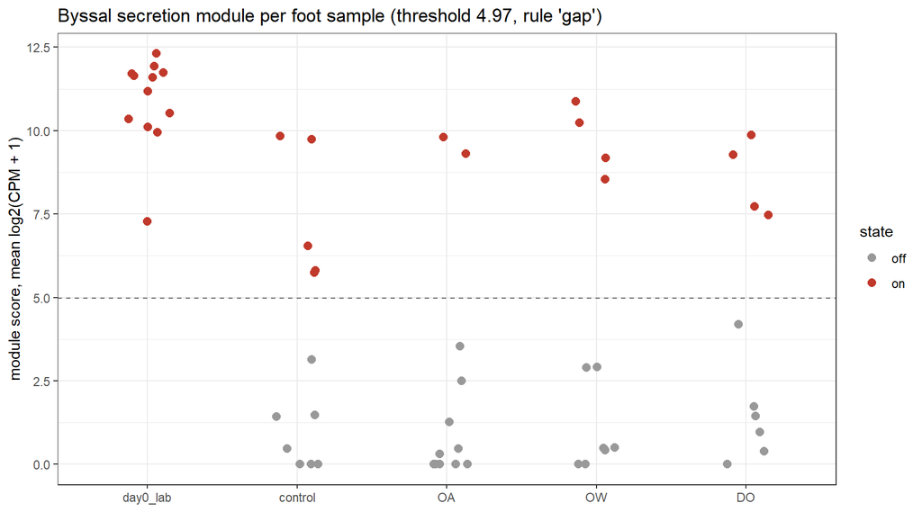

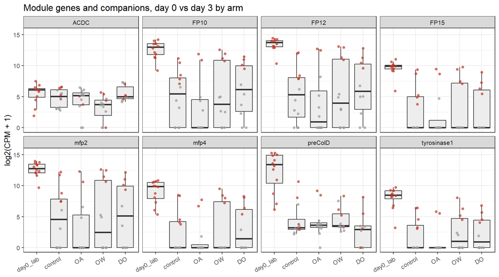

```r
write_csv(summ, OUT_SUMMARY)

p1 <- ggplot(state %>% mutate(group = factor(group, levels = levels(long$group))),
             aes(group, secretion_score)) +
  geom_hline(yintercept = threshold, linetype = "dashed", colour = "grey40") +
  geom_jitter(aes(colour = secretion_state), width = 0.15, height = 0, size = 2.4) +
  scale_colour_manual(values = c(off = "grey60", on = "#c0392b"), name = "state") +
  labs(x = NULL, y = "module score, mean log2(CPM + 1)",
       title = sprintf("Byssal secretion module per foot sample (threshold %.2f, rule '%s')",
                       threshold, as.character(ON_RULE))) +
  theme_bw(base_size = 11)
p2 <- ggplot(long, aes(group, log2cpm)) +
  geom_boxplot(outlier.shape = NA, fill = "grey93") +
  geom_jitter(aes(colour = secretion_state), width = 0.15, height = 0, size = 1.2, alpha = 0.7) +
  scale_colour_manual(values = c(off = "grey60", on = "#c0392b"), guide = "none") +
  facet_wrap(~ gene, nrow = 2) +
  labs(x = NULL, y = "log2(CPM + 1)", title = "Module genes and companions, day 0 vs day 3 by arm") +
  theme_bw(base_size = 10) + theme(axis.text.x = element_text(angle = 30, hjust = 1))
print(p1); print(p2)
```

```r
png(OUT_FIG, width = 2400, height = 2000, res = 200)
gridExtra_ok <- requireNamespace("gridExtra", quietly = TRUE)
if (gridExtra_ok) gridExtra::grid.arrange(p1, p2, ncol = 1, heights = c(1, 1.4)) else { print(p1); print(p2) }
dev.off()
```

# Notes

- The state is an expression-derived quantity measured on the same foot sample as the contrast it might be used to adjust. Adjusting a foot contrast for it removes the module’s own variance and everything correlated with it; that is the point when the question is “what does the stressor do beyond secretion state”, and a bias when the stressor itself changes the secretion rate. Report both fits (`02_7`), never only the adjusted one.
- Day-0 animals were pulled from the field/holding directly into sampling, so any day-0 comparison (LC contrasts) also carries any day-0 vs day-3 difference in secretion state and everything downstream of it (tested in `secretion_state_by_arm.csv`); this is one reason the LC contrasts are not used as stressor effects (README).